# MrOS_DMM_8clusters

Kate Bowie

2024-12-28

# Purpose

Examining clusters made using DMM from MrOS_subcat_DMM.RMD

# Set-up

```r
library(here)
library(phyloseq)
library(tidyverse)
```

```r
library(ggplot2)
library(microshades)
library(patchwork)
library(ggpubr)
library(cowplot)
library(rstatix)
library(microbiome)
library(reshape2)
library(magrittr)
library(tableone)
library(speedyseq)
# necessary for ANCOVA
library(broom)
library(datarium)
library(WRS2)
```

# Data origin

This ps object was cleaned up in Box/Kate/MrOS/data/Analyses/MrOS_EDA.Rmd. ALl of the data is described explicitly in that RMD. The ps object is *rarefied*

I chose which clustering to try in MrOS_subcat_DMM.RMD which is located one One Drive: MrOS/data/Analyses

```r
load(here("data", "Final_Analyses", "ps_dmm.RData"))

ps <- ps_orig
sample_data(ps) <- new_sam
```

# Remove NAs

```r
new_sam <- new_sam %>% filter(!(is.na(k_8)))
sample_data(ps) <- new_sam
```

There are two samples that do not cluster, thus their clustering designation is NA and should be removed from subsequent analyses.

```r
tertiles <- quantile(new_sam$age, c(0:3/3))# classify values
new_sam$age_group = with(new_sam,
               cut(age,
                   tertiles,
                   include.lowest = T,
                   labels = c("age1", "age2", "age3")))
```

# Plot

```r
mdf <- ps %>%
          psmelt()
```

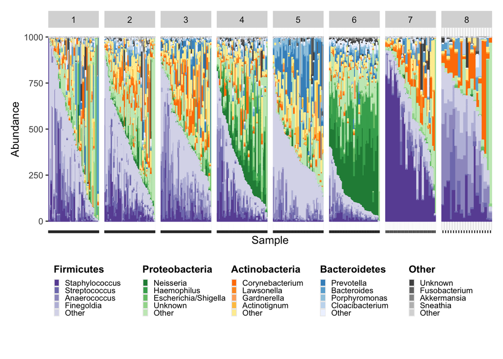

```r
color_dfs <- create_color_dfs(mdf, group_level = "Phylum", subgroup_level = "Genus")

color_dfs <- reorder_samples_by(color_dfs$mdf,color_dfs$cdf, order_tax = "Firmicutes")

plot_g <- plot_microshades(color_dfs$mdf,color_dfs$cdf)

cust_legend <-custom_legend(color_dfs$mdf, color_dfs$cdf, group_level = "Phylum", subgroup_level = "Genus", legend_orientation = "horizontal") #legend_key_size = 0.4, legend_text_size = 12,
dmm_plot <- plot_g + facet_grid(~k_8, scales = "free_x") + theme(legend.position = "none", axis.text.x = element_blank(), legend.title = element_blank())


clus_plot <- dmm_plot / plot_spacer() / cust_legend + plot_layout(heights = c(1.6, -0.28, 1))
clus_plot
```

# Test for Anova Function

```r
stat_check <- function(results_alpha, diversity_metric, group_variable){
args <- substitute(diversity_metric ~ group_variable, list(diversity_metric = as.name(diversity_metric), group_variable = as.name(group_variable)))
div_model <- lm(args, data = results_alpha)
print("shapiro_test")
print(shapiro_test(residuals(div_model)))
print("levene_test")
print(levene_test(args, data = div_model))

print(ggqqplot(residuals(div_model)))
}
```

# Cluster Overview

```r
table(ps@sam_data$k_8)
```

```
##
##  1  2  3  4  5  6  7  8
## 85 89 65 61 59 58 37 19
```

There are 8 clusters that have between 19-89 samples per cluster. I go into more detail next.

pi theta 0.2055101 5.516766  
0.1551565 9.088939  
0.1386909 5.802908  
0.1289031 9.280307  
0.1256028 1.596186  
0.1238225 27.625753  
0.1225153 10.762756

# Sequencing summary

```r
new_sam %>%
  group_by(k_8) %>%
  get_summary_stats(SampleSums, show = c("n", "min", "max", "mean", "median", "sd"))
```

| k_8 | variable | n | min | max | mean | median | sd |
| --- | --- | --- | --- | --- | --- | --- | --- |
| 1 | SampleSums | 85 | 1018 | 101017 | 17702.835 | 10301 | 20167.654 |
| 2 | SampleSums | 89 | 1260 | 54805 | 9697.652 | 6411 | 9252.479 |
| 3 | SampleSums | 65 | 1917 | 49287 | 17975.815 | 16880 | 9597.450 |
| 4 | SampleSums | 61 | 1197 | 39214 | 13146.902 | 11482 | 9022.644 |
| 5 | SampleSums | 59 | 3047 | 56876 | 34110.847 | 36394 | 11970.489 |
| 6 | SampleSums | 58 | 5551 | 60691 | 22147.569 | 22484 | 9460.370 |
| 7 | SampleSums | 37 | 1383 | 33152 | 9589.595 | 6634 | 8268.392 |
| 8 | SampleSums | 19 | 2101 | 38186 | 13753.263 | 11716 | 9620.152 |

### Testing normality

```r
ssums <- new_sam %>%
  select(SampleSums, k_8)

ssums$k_8 <- as.character(new_sam$k_8)

stat_check(ssums, diversity_metric = "SampleSums", group_variable ="k_8")
```

```
## [1] "shapiro_test"
## # A tibble: 1 × 3
##   variable             statistic  p.value
##   <chr>                    <dbl>    <dbl>
## 1 residuals(div_model)     0.896 2.04e-17
## [1] "levene_test"
```

```
## # A tibble: 1 × 4
##     df1   df2 statistic            p
##   <int> <int>     <dbl>        <dbl>
## 1     7   465      7.17 0.0000000372
```

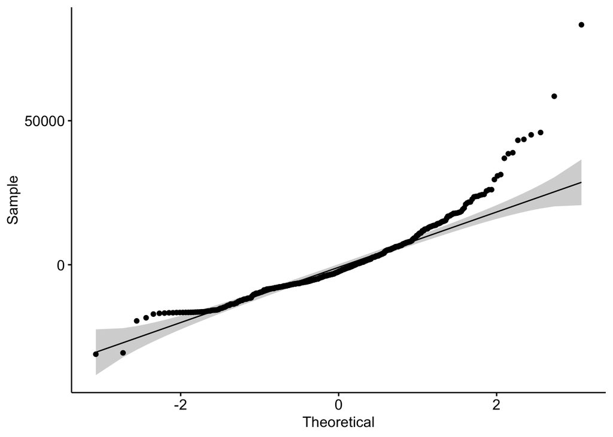

non-normal and non-homogeneous

### Stats

```r
kruskal.test(new_sam$SampleSums ~ new_sam$k_8)
```

```
##
##  Kruskal-Wallis rank sum test
##
## data:  new_sam$SampleSums by new_sam$k_8
## Kruskal-Wallis chi-squared = 144.97, df = 7, p-value < 2.2e-16
```

```r
pairwise.wilcox.test(new_sam$SampleSums, new_sam$k_8,
                 p.adjust.method = "BH")
```

```
##
##  Pairwise comparisons using Wilcoxon rank sum test with continuity correction
##
## data:  new_sam$SampleSums and new_sam$k_8
##
##   1       2       3       4       5       6       7
## 2 0.22494 -       -       -       -       -       -
## 3 0.02493 1.7e-08 -       -       -       -       -
## 4 0.59731 0.00516 0.00296 -       -       -       -
## 5 6.8e-09 < 2e-16 7.5e-11 2.1e-13 -       -       -
## 6 0.00092 2.1e-12 0.00830 6.5e-07 1.0e-07 -       -
## 7 0.39770 0.86390 9.5e-06 0.03605 3.1e-12 1.2e-08 -
## 8 0.60482 0.04832 0.08378 0.86390 6.2e-07 0.00176 0.08774
##
## P value adjustment method: BH
```

There are significant differences in the average sequencing reads between clusters.

Only NON-significant clusters: - 2 v 1 - 4 v 1 - 7 v 1 - 7 v 2 - 8 v 1 - 8 v 3 - 8 v 4 - 8 v 7

# Clinical Char.

```r
clin_char <- new_sam %>%
  select(LUTS_cat, age, Race, BMI_group, Diabetes, Prostatitis, BPH, Cancer_Type, QoL, age_group, PS_Irritative, PS_Obstructive, k_8)

clin_table <- CreateTableOne(strata = "k_8", data = clin_char, factorVars = "Race")
print(clin_table)
```

```
##                                 Stratified by k_8
##                                  1             2             3
##   n                                 85            89            65
##   LUTS_cat = moderate/severe (%)    35 (41.2)     43 (48.3)     27 (41.5)
##   age (mean (SD))                73.34 (5.33)  72.25 (5.14)  73.18 (6.14)
##   Race = 2. Other (%)               10 (11.8)     10 (11.2)     11 (16.9)
##   BMI_group (%)
##      healthy_weight                 15 (17.6)     24 (27.0)     13 (20.0)
##      obesity                        26 (30.6)     17 (19.1)     14 (21.5)
##      overweight                     44 (51.8)     48 (53.9)     38 (58.5)
##   Diabetes (%)
##                                      8 ( 9.4)     11 (12.4)      4 ( 6.2)
##      0. No                          65 (76.5)     69 (77.5)     55 (84.6)
##      1. Yes                         12 (14.1)      9 (10.1)      6 ( 9.2)
##   Prostatitis = Yes (%)             25 (29.4)     20 (22.5)     13 (20.0)
##   BPH = Yes (%)                     44 (51.8)     48 (53.9)     29 (44.6)
##   Cancer_Type (%)
##      None                           60 (70.6)     54 (60.7)     42 (64.6)
##      Other                          10 (11.8)     23 (25.8)     10 (15.4)
##      Prostate                       15 (17.6)     12 (13.5)     13 (20.0)
##   QoL (%)
##      Happy                          64 (75.3)     60 (67.4)     44 (67.7)
##      Mixed                          11 (12.9)     19 (21.3)     13 (20.0)
##      Unhappy                        10 (11.8)     10 (11.2)      8 (12.3)
##   age_group (%)
##      age1                           30 (35.3)     38 (42.7)     26 (40.0)
##      age2                           27 (31.8)     26 (29.2)     19 (29.2)
##      age3                           28 (32.9)     25 (28.1)     20 (30.8)
##   PS_Irritative (mean (SD))       4.48 (3.38)   4.53 (2.85)   4.75 (3.04)
##   PS_Obstructive (mean (SD))      3.09 (4.08)   4.24 (4.01)   2.65 (3.04)
##   k_8 (mean (SD))                 1.00 (0.00)   2.00 (0.00)   3.00 (0.00)
##                                 Stratified by k_8
##                                  4             5             6
##   n                                 61            59            58
##   LUTS_cat = moderate/severe (%)    24 (39.3)     33 (55.9)     27 (46.6)
##   age (mean (SD))                73.20 (5.16)  73.80 (5.97)  71.69 (6.04)
##   Race = 2. Other (%)                8 (13.1)      3 ( 5.1)      6 (10.3)
##   BMI_group (%)
##      healthy_weight                 12 (19.7)      6 (10.2)     17 (29.3)
##      obesity                        12 (19.7)     25 (42.4)     11 (19.0)
```

[output cut: 38 more lines]

```
##   Cancer_Type (%)                                             0.255
##      None                           24 (64.9)     14 (73.7)
##      Other                           9 (24.3)      1 ( 5.3)
##      Prostate                        4 (10.8)      4 (21.1)
##   QoL (%)                                                     0.604
##      Happy                          25 (67.6)     16 (84.2)
##      Mixed                           7 (18.9)      1 ( 5.3)
##      Unhappy                         5 (13.5)      2 (10.5)
##   age_group (%)                                               0.366
##      age1                           18 (48.6)      7 (36.8)
##      age2                            7 (18.9)      5 (26.3)
##      age3                           12 (32.4)      7 (36.8)
##   PS_Irritative (mean (SD))       4.24 (2.69)   3.74 (2.23)   0.400
##   PS_Obstructive (mean (SD))      3.00 (3.04)   2.95 (3.58)   0.121
##   k_8 (mean (SD))                 7.00 (0.00)   8.00 (0.00)  <0.001
```

The only significant differences between clusters is with BMI, both as a continuous and grouped variable.

# Trend plots

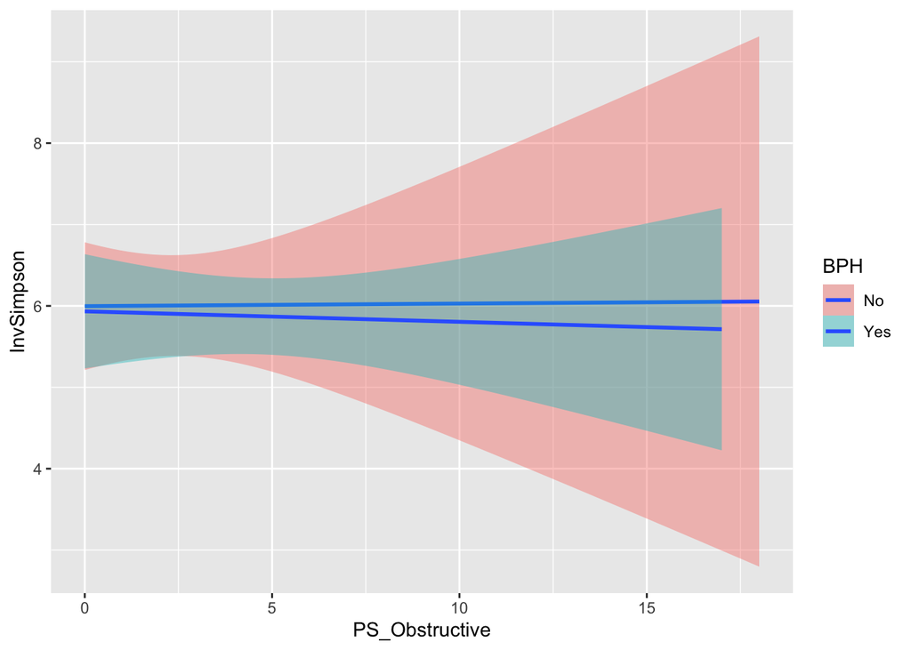

```r
# fixing factored BMI
new_sam$BMI_title <- "overweight"
new_sam$BMI_title[new_sam$BMI_group == "healthy_weight"] <- "healthy weight"
new_sam$BMI_title[new_sam$BMI_group == "obesity"] <- "obese"
new_sam$BMI_title <- factor(new_sam$BMI_title, levels = c("healthy weight", "overweight", "obese"))

not_obs_line <- new_sam %>%
  filter(BMI_group != "obesity") %>%
  ggplot(., aes(x = PS_Obstructive, y = InvSimpson, fill = BPH)) +
  geom_smooth(method = "lm")

not_obs_line
```

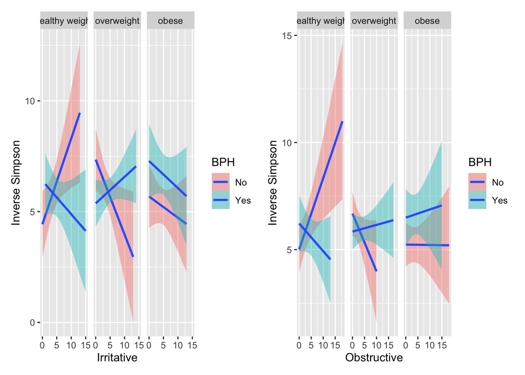

```r
Obs_line <- new_sam %>%
  ggplot(., aes(x = PS_Obstructive, y = InvSimpson, fill = BPH)) +
  geom_smooth(method = "lm") + facet_wrap(~BMI_title) + xlab("Obstructive") + ylab("Inverse Simpson")


Irr_line <- new_sam %>%
  ggplot(., aes(x = PS_Irritative, y = InvSimpson, fill = BPH)) +
  geom_smooth(method = "lm") + facet_wrap(~BMI_title) + xlab("Irritative") + ylab("Inverse Simpson")

Irr_line + Obs_line
```

### BMI pairwise

```r
wilcox_results <- pairwise.wilcox.test(new_sam$HWBMI.x, new_sam$k_8,
                 p.adjust.method = "BH")

wilcox_results
```

```
##
##  Pairwise comparisons using Wilcoxon rank sum test with continuity correction
##
## data:  new_sam$HWBMI.x and new_sam$k_8
##
##   1     2     3     4     5     6     7
## 2 0.208 -     -     -     -     -     -
## 3 0.644 0.418 -     -     -     -     -
## 4 0.331 0.644 0.644 -     -     -     -
## 5 0.129 0.019 0.097 0.043 -     -     -
## 6 0.331 0.644 0.724 0.985 0.048 -     -
## 7 0.043 0.208 0.079 0.129 0.004 0.129 -
## 8 0.644 0.331 0.641 0.418 0.591 0.418 0.097
##
## P value adjustment method: BH
```

Can I make a balloonplot for this? (balloonplot(t(dt), main =“housetasks”, xlab =““, ylab=”“, label = FALSE, show.margins = FALSE)).. part of gplots package. Example from below: http://www.sthda.com/english/wiki/chi-square-test-of-independence-in-r

#### plot fun

```r
library(gplots)
wilcox_results <- data.frame(wilcox_results$p.value)
#wilcox_results %>%
  #pivot_longer(., names_to = "clusters", values_to = "p_values")

#balloonplot(chitest2$k_8, chitest2$BMI_group, chitest2$n, xlab = "", ylab = "BMI", main = "Clusters", label = FALSE, show.margins = FALSE)
```

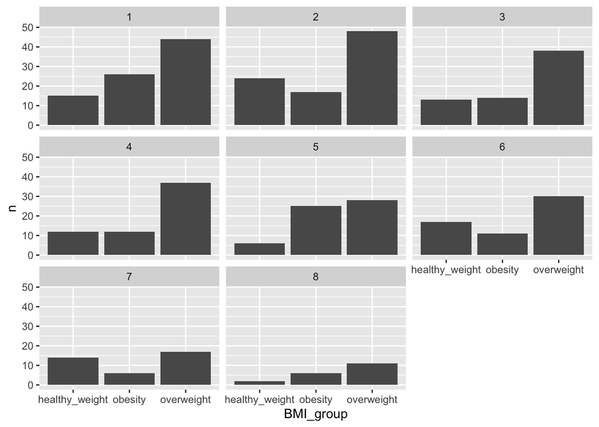

```r
new_sam %>%
  group_by(k_8, BMI_group) %>%
  dplyr::count(BMI_group) %>%
  ggplot(., aes(x = BMI_group, y = n)) + geom_col() + facet_wrap(~k_8)
```

#### chi-square fun times

Chi-square test examines whether rows and columns of a contingency table are statistically significantly associated.

Null hypothesis (H0): the row and the column variables of the contingency table are independent. Alternative hypothesis (H1): row and column variables are dependent

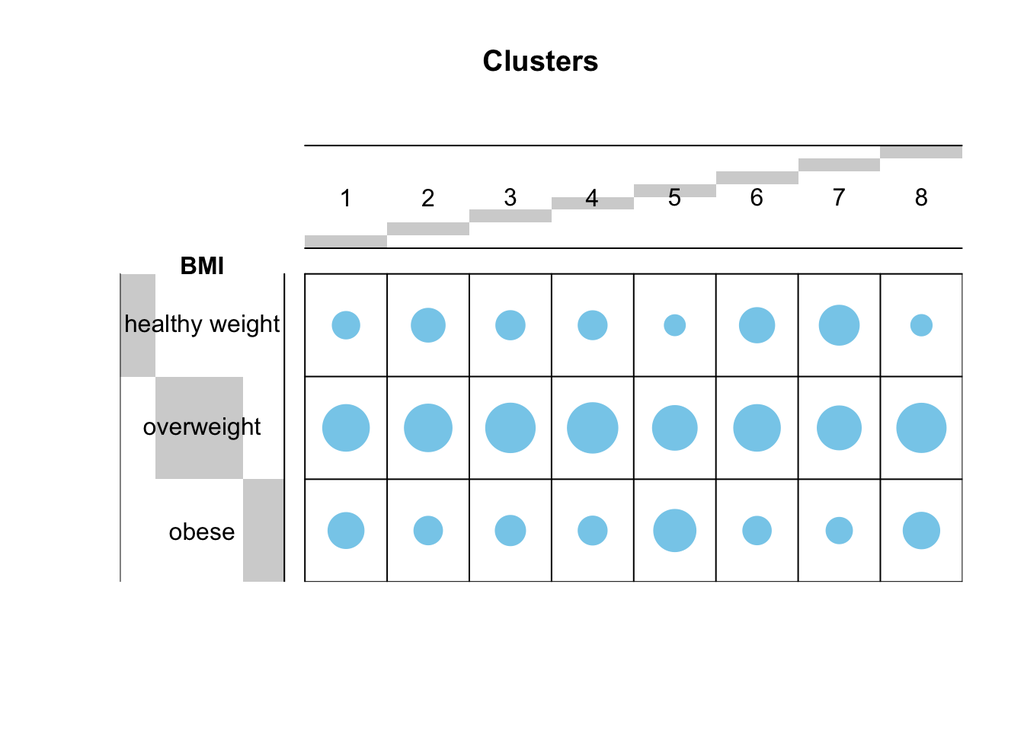

```r
new_sam$BMI_group <- factor(new_sam$BMI_group, levels = c("healthy_weight", "overweight", "obesity"))


chitest2 <- new_sam %>%
  group_by(k_8, BMI_title) %>%
  dplyr::count(BMI_title) %>%
  dplyr::mutate(cluster_n = case_when(
    k_8 == 1 ~ 85,
    k_8 == 2 ~ 89,
    k_8 == 3 ~ 65,
    k_8 == 4 ~ 61,
    k_8 == 5 ~ 59,
    k_8 == 6 ~ 58,
    k_8 == 7 ~ 37,
    k_8 == 8 ~ 19,
  ))

chitest2$n_norm <- chitest2$n/chitest2$cluster_n

bplot <- chitest2


balloonplot(bplot$k_8, bplot$BMI_title, bplot$n_norm, xlab = "", ylab = "BMI", main = "Clusters", label = FALSE, show.margins = FALSE)
```

```r
chitest2 <- chitest2 %>%
  select(-n_norm, -cluster_n) %>%
  pivot_wider(names_from = k_8, values_from = n) %>%
  data.frame()

row.names(chitest2) <- chitest2$BMI_title

chitest2 <- chitest2 %>%
  select(-BMI_title) %>%
  as.matrix()



chisq <- chisq.test(chitest2)
chisq$p.value
```

```
## [1] 0.01741294
```

```r
#rm(chitest2)
```

#### stacked barplot

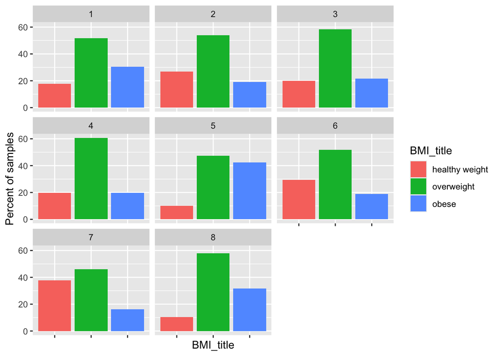

```r
bplot %>%
  ggplot(., aes(x = BMI_title, y = (n_norm)*100, fill = BMI_title)) +
  geom_col() +
  facet_wrap(~k_8) +
  ylab("Percent of samples") + theme(axis.text.x=element_blank())
```

```r
splot <- bplot %>%
  ggplot(., aes(x = as.factor(k_8), y = (n_norm)*100, fill = BMI_title)) +
  geom_bar(stat = "identity") +
  ylab("Percent of samples") +
  scale_fill_brewer(palette = "Paired") +
  xlab("Urotype") +
  guides(fill=guide_legend(title="BMI"))




bmi_sep <- bplot %>%
  ggplot(., aes(x = as.factor(k_8), y = (n_norm)*100, fill = BMI_title)) +
  geom_bar(stat = "identity") +
  theme(legend.position = "none") +
  facet_wrap(~BMI_title, nrow = 3) +
  ylab("Percent of samples") +
  scale_fill_manual(values=c("#66C2A5", "#8DA0CB","#FC8D62")) +
  xlab("Urotype")
```

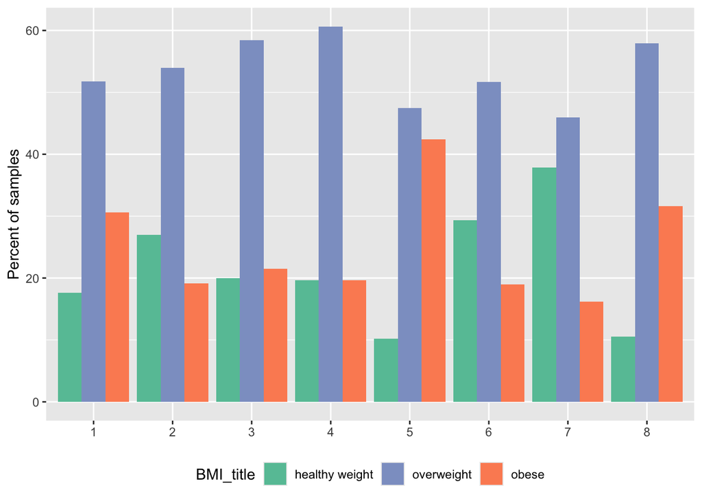

```r
bplot <- bplot %>%
  mutate(perc_n = n_norm*100)

bmi_cols <- bplot %>%
  ggplot(., aes(x = factor(k_8), y = perc_n, fill = BMI_title)) + geom_col(position = "dodge") +
  scale_fill_manual(values=c("#66C2A5", "#8DA0CB","#FC8D62")) +
  theme(legend.position = "bottom", axis.title.x = element_blank()) +
  ylab("Percent of samples")

plot(bmi_cols)
```

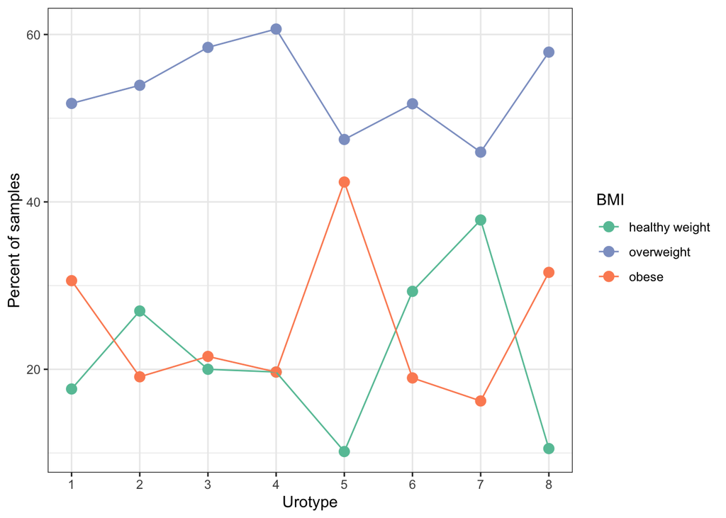

```r
mybreaks = c(1:8)

bmi_traces <- bplot %>%
  ggplot(., aes(x = k_8, y = perc_n, color = BMI_title)) + geom_point(size = 3) +
  geom_line() +
  guides(colour=guide_legend(title="BMI")) +
  scale_x_continuous(breaks = mybreaks,
                     labels = mybreaks,
                     minor_breaks = NULL) +
  ylab("Percent of samples") +
  scale_color_manual(values=c("#66C2A5", "#8DA0CB","#FC8D62")) +
  xlab("Urotype") + theme_bw()

bmi_traces
```

#### pie chart chaos option

```r
bmi_pie <- bplot %>%
  ggplot(., aes(x = k_8, y = perc_n, fill = BMI_title)) +
  scale_fill_manual(values=c("#66C2A5", "#8DA0CB","#FC8D62")) +
  geom_bar(stat="identity", width=1, color="white") +
  coord_polar("y", start = 0) +
  theme_void() +
  theme(legend.position = "bottom") +
  facet_wrap(~k_8, scales = "free", nrow = 1)
```

#### pairwise chisquare

```r
#chi_result <- pairwise_chisq_test_against_p(chitest2, p.adjust.method = "BH")
# new errors with this 03/2024
```

##### clean up

```r
rm(chisq, bplot, clin_char, clin_table, Obs_line, ssums, chitest2)
```

# Alpha Div

```r
results_alpha <- new_sam %>% select(Observed, Shannon, InvSimpson, pielou, k_8)
results_alpha$k_8 <- as.character(results_alpha$k_8)
```

## Testing Alpha div Anova

#### Observed

```r
stat_check(results_alpha, diversity_metric = "Observed", group_variable ="k_8")
```

```
## [1] "shapiro_test"
## # A tibble: 1 × 3
##   variable             statistic  p.value
##   <chr>                    <dbl>    <dbl>
## 1 residuals(div_model)     0.868 1.34e-19
## [1] "levene_test"
```

```
## # A tibble: 1 × 4
##     df1   df2 statistic     p
##   <int> <int>     <dbl> <dbl>
## 1     7   465      1.26 0.267
```

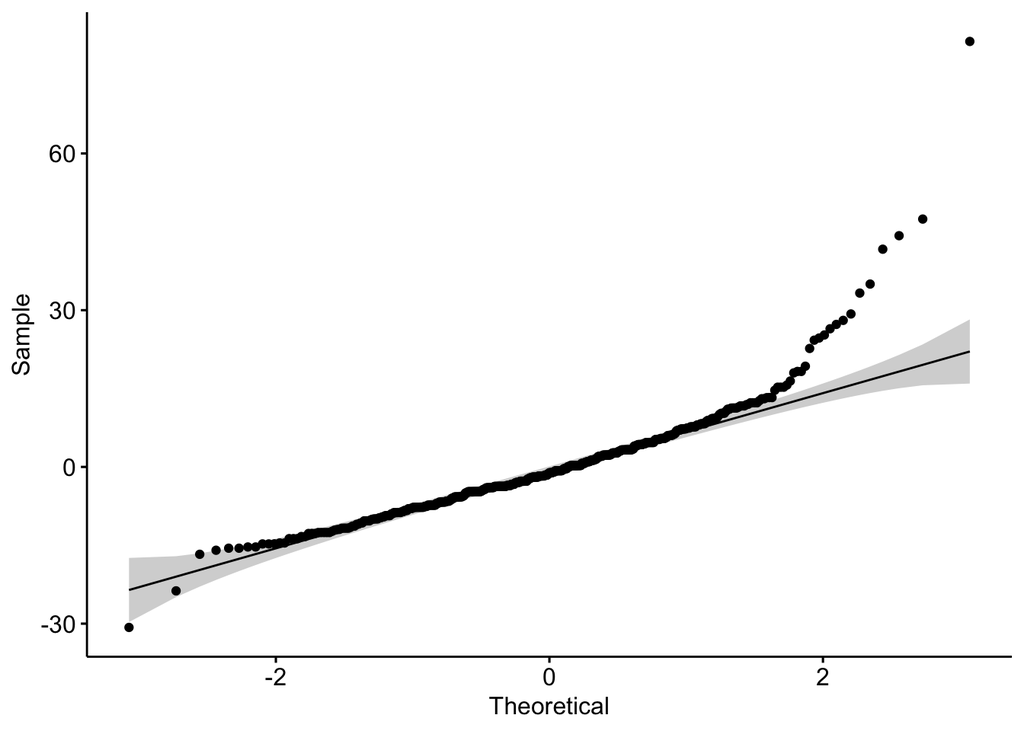

The result of the Shapiro test is that the observed data is NOT normal (since the p-val is significant). This means we’ll need to use the non-parametic test, kruskal-wallis.

The result of the levene test is that the p-val is insignificant, therefore the variances across groups are not different.

As the data is non-normal yet homogeneous, we will need to do the wilcox_test for posthoc analysis.

#### Shannon

```r
stat_check(results_alpha, diversity_metric = "Shannon", group_variable ="k_8")
```

```
## [1] "shapiro_test"
## # A tibble: 1 × 3
##   variable             statistic     p.value
##   <chr>                    <dbl>       <dbl>
## 1 residuals(div_model)     0.977 0.000000658
## [1] "levene_test"
```

```
## # A tibble: 1 × 4
##     df1   df2 statistic           p
##   <int> <int>     <dbl>       <dbl>
## 1     7   465      6.68 0.000000149
```

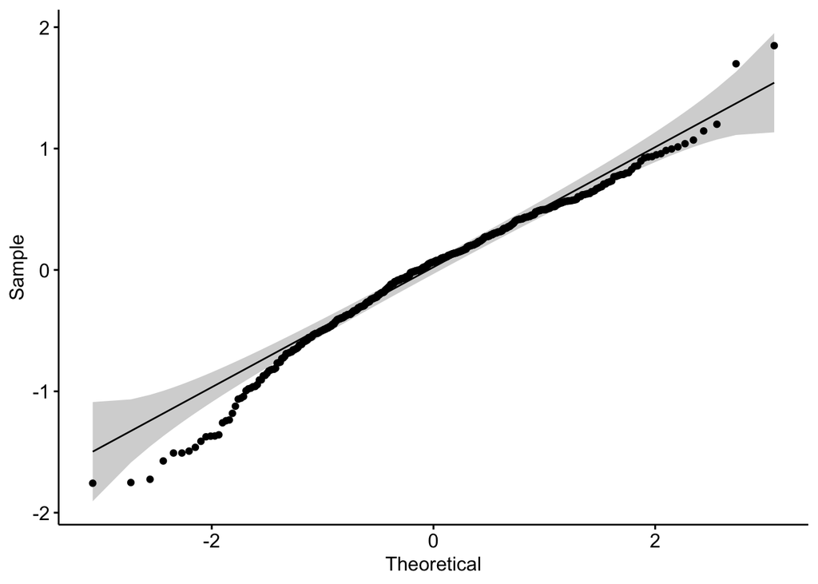

Non-normal and non-homogeneous data

(aka use kruskal-wallis and wilcox test)

#### Inv Simpson

```r
stat_check(results_alpha, diversity_metric = "InvSimpson", group_variable ="k_8")
```

```
## [1] "shapiro_test"
## # A tibble: 1 × 3
##   variable             statistic  p.value
##   <chr>                    <dbl>    <dbl>
## 1 residuals(div_model)     0.846 4.88e-21
## [1] "levene_test"
```

```
## # A tibble: 1 × 4
##     df1   df2 statistic        p
##   <int> <int>     <dbl>    <dbl>
## 1     7   465      4.19 0.000171
```

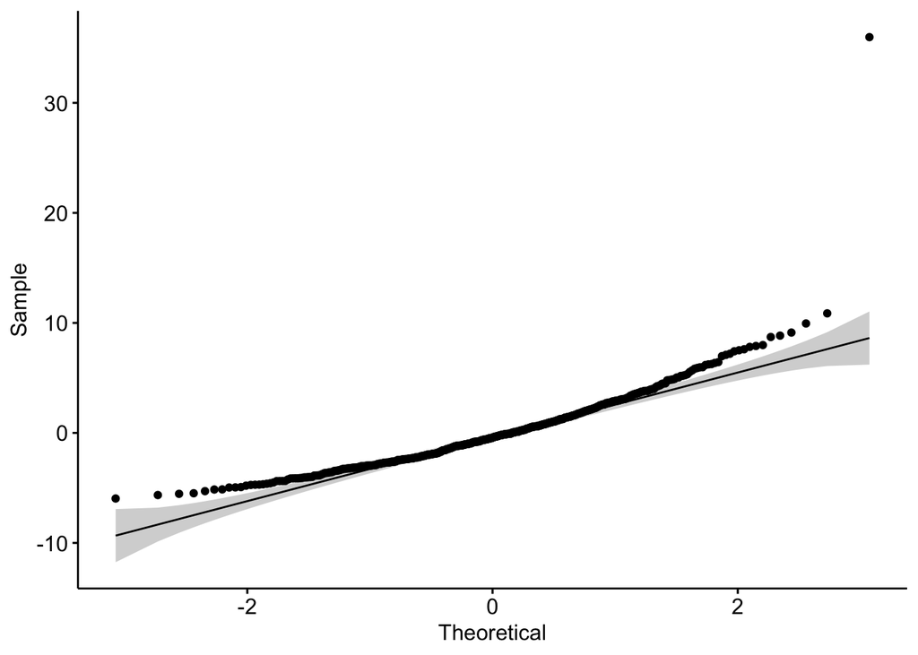

Non-normal dataaaa non-homogeneous dataaaa

#### Pielou

```r
stat_check(results_alpha, diversity_metric = "pielou", group_variable ="k_8")
```

```
## [1] "shapiro_test"
## # A tibble: 1 × 3
##   variable             statistic  p.value
##   <chr>                    <dbl>    <dbl>
## 1 residuals(div_model)     0.958 2.00e-10
## [1] "levene_test"
```

```
## # A tibble: 1 × 4
##     df1   df2 statistic        p
##   <int> <int>     <dbl>    <dbl>
## 1     7   465      15.1 7.67e-18
```

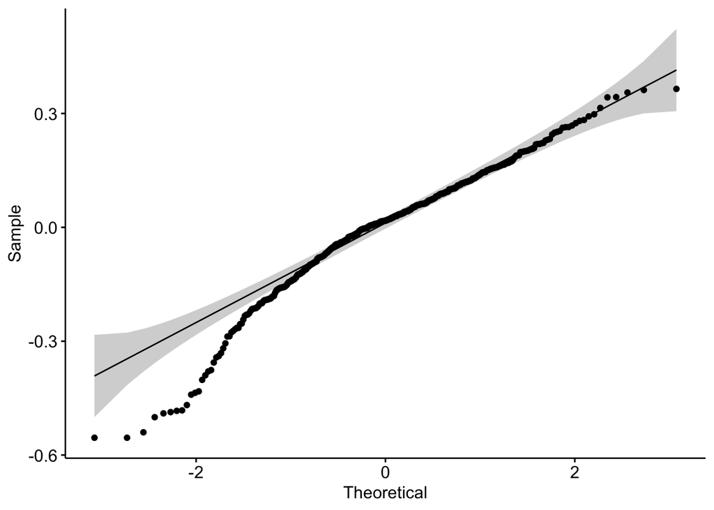

Non-normal dataaaa non-homogeneous dataaaa

In conclusion, Shannon, Inverse Simpson, and pielou are all non-normal and non-homogeneous. Observed is non-normal but homogeneous.

## Examining Alpha div

```r
a_div <- new_sam %>%
  select(BPH, Observed, Shannon, InvSimpson, pielou, k_8)

adiv_table <- CreateTableOne(strata = c("k_8", "BPH"), data = a_div)
print(adiv_table, nonnormal = c("Observed", "Shannon", "InvSimpson", "pielou"))
```

```
##                            Stratified by k_8:BPH
##                             1:No                 2:No
##   n                            41                   41
##   BPH = Yes (%)                 0 (0.0)              0 (0.0)
##   Observed (median [IQR])   13.00 [10.00, 18.00] 27.00 [19.00, 31.00]
##   Shannon (median [IQR])     1.61 [0.69, 2.00]    2.14 [1.72, 2.68]
##   InvSimpson (median [IQR])  3.05 [1.68, 6.01]    5.39 [3.15, 9.97]
##   pielou (median [IQR])      0.56 [0.36, 0.77]    0.72 [0.57, 0.81]
##   k_8 (mean (SD))            1.00 (0.00)          2.00 (0.00)
##                            Stratified by k_8:BPH
##                             3:No                 4:No
##   n                            36                   34
##   BPH = Yes (%)                 0 (0.0)              0 (0.0)
##   Observed (median [IQR])   32.00 [26.75, 35.00] 30.00 [27.00, 38.75]
##   Shannon (median [IQR])     2.33 [1.98, 2.55]    2.32 [2.05, 2.63]
##   InvSimpson (median [IQR])  6.08 [4.08, 8.67]    6.14 [4.33, 8.19]
##   pielou (median [IQR])      0.68 [0.58, 0.75]    0.68 [0.62, 0.77]
##   k_8 (mean (SD))            3.00 (0.00)          4.00 (0.00)
##                            Stratified by k_8:BPH
##                             5:No                 6:No
##   n                            31                   30
##   BPH = Yes (%)                 0 (0.0)              0 (0.0)
##   Observed (median [IQR])   26.00 [22.00, 30.50] 33.00 [30.00, 38.00]
##   Shannon (median [IQR])     2.10 [1.73, 2.38]    2.11 [1.93, 2.28]
##   InvSimpson (median [IQR])  5.56 [3.61, 7.23]    4.55 [3.73, 5.65]
##   pielou (median [IQR])      0.64 [0.57, 0.70]    0.61 [0.57, 0.64]
##   k_8 (mean (SD))            5.00 (0.00)          6.00 (0.00)
##                            Stratified by k_8:BPH
##                             7:No                 8:No
##   n                            21                   12
##   BPH = Yes (%)                 0 (0.0)              0 (0.0)
##   Observed (median [IQR])   18.00 [15.00, 22.00] 21.00 [20.75, 23.50]
##   Shannon (median [IQR])     1.90 [1.39, 2.10]    2.07 [1.84, 2.13]
##   InvSimpson (median [IQR])  4.42 [2.70, 5.87]    5.04 [3.80, 6.07]
##   pielou (median [IQR])      0.62 [0.46, 0.75]    0.67 [0.55, 0.72]
##   k_8 (mean (SD))            7.00 (0.00)          8.00 (0.00)
##                            Stratified by k_8:BPH
##                             1:Yes                2:Yes
##   n                            44                   48
##   BPH = Yes (%)                44 (100.0)           48 (100.0)
```

[output cut: 26 more lines]

```
##   BPH = Yes (%)                16 (100.0)            7 (100.0)        <0.001
##   Observed (median [IQR])   23.00 [16.25, 25.75] 20.00 [18.50, 26.00] <0.001
##   Shannon (median [IQR])     1.91 [1.14, 2.44]    1.90 [1.77, 2.07]   <0.001
##   InvSimpson (median [IQR])  4.35 [1.68, 7.11]    5.00 [4.38, 5.40]   <0.001
##   pielou (median [IQR])      0.63 [0.37, 0.75]    0.63 [0.61, 0.70]    0.001
##   k_8 (mean (SD))            7.00 (0.00)          8.00 (0.00)         <0.001
##                            Stratified by k_8:BPH
##                             test
##   n
##   BPH = Yes (%)
##   Observed (median [IQR])   nonnorm
##   Shannon (median [IQR])    nonnorm
##   InvSimpson (median [IQR]) nonnorm
##   pielou (median [IQR])     nonnorm
##   k_8 (mean (SD))
```

### Observed plotted

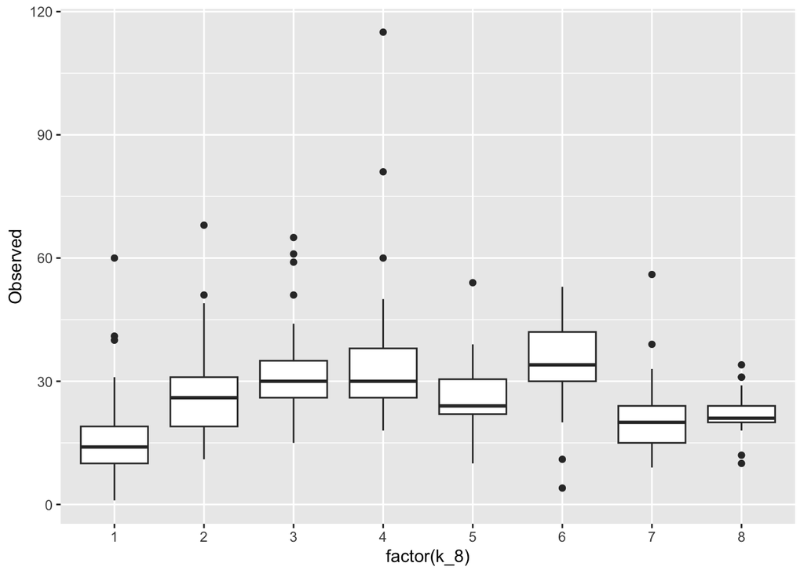

```r
ggplot(new_sam, aes(x = factor(k_8), y = Observed)) + geom_boxplot()
```

```r
pairwise.wilcox.test(new_sam$Observed, new_sam$k_8,
                 p.adjust.method = "BH")
```

```
##
##  Pairwise comparisons using Wilcoxon rank sum test with continuity correction
##
## data:  new_sam$Observed and new_sam$k_8
##
##   1       2       3       4       5       6       7
## 2 1.3e-13 -       -       -       -       -       -
## 3 < 2e-16 0.00036 -       -       -       -       -
## 4 < 2e-16 0.00017 0.61452 -       -       -       -
## 5 6.0e-12 0.97185 0.00034 0.00021 -       -       -
## 6 < 2e-16 1.1e-07 0.01206 0.04367 3.3e-07 -       -
## 7 0.00034 0.00074 2.3e-08 3.7e-08 0.00068 3.8e-09 -
## 8 0.00021 0.10391 3.9e-05 4.8e-05 0.03019 2.1e-06 0.35715
##
## P value adjustment method: BH
```

### pielou

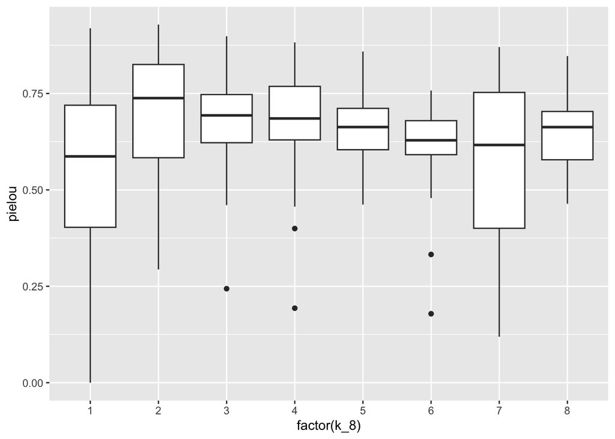

```r
ggplot(new_sam, aes(x = factor(k_8), y = pielou)) + geom_boxplot()
```

```r
pairwise.wilcox.test(new_sam$pielou, new_sam$k_8,
                 p.adjust.method = "BH")
```

```
##
##  Pairwise comparisons using Wilcoxon rank sum test with continuity correction
##
## data:  new_sam$pielou and new_sam$k_8
##
##   1      2      3      4      5      6      7
## 2 0.0014 -      -      -      -      -      -
## 3 0.0086 0.1573 -      -      -      -      -
## 4 0.0086 0.2867 0.9416 -      -      -      -
## 5 0.0809 0.0139 0.1536 0.2268 -      -      -
## 6 0.3064 0.0019 0.0039 0.0086 0.1536 -      -
## 7 0.6664 0.0285 0.2585 0.1983 0.6759 0.8956 -
## 8 0.2867 0.1536 0.3064 0.3196 0.8689 0.4739 0.6664
##
## P value adjustment method: BH
```

Significant groups: - 2 v 1 - 3 v 1 - 4 v 1 - 5 v 2 - 6 v 2 - 6 v 3 - 6 v 4 - 7 v 2

### Shannon Index

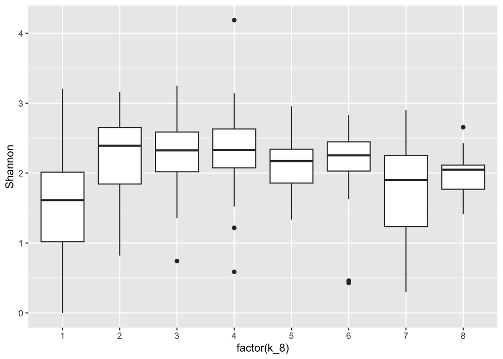

```r
ggplot(new_sam, aes(x = factor(k_8), y = Shannon)) + geom_boxplot()
```

```r
pairwise.wilcox.test(new_sam$Shannon, new_sam$k_8,
                 p.adjust.method = "BH")
```

```
##
##  Pairwise comparisons using Wilcoxon rank sum test with continuity correction
##
## data:  new_sam$Shannon and new_sam$k_8
##
##   1       2       3       4       5       6       7
## 2 4.6e-10 -       -       -       -       -       -
## 3 5.7e-11 0.62578 -       -       -       -       -
## 4 7.7e-11 0.58747 0.84901 -       -       -       -
## 5 6.9e-07 0.04315 0.00347 0.00358 -       -       -
## 6 9.2e-09 0.39492 0.16356 0.14843 0.11023 -       -
## 7 0.10613 0.00101 0.00014 0.00014 0.02800 0.00276 -
## 8 0.01541 0.03042 0.00255 0.00276 0.15120 0.01438 0.44784
##
## P value adjustment method: BH
```

The only NON-Significant groups: - 3 v 2 - 4 v 2 - 4 v 3 - 6 v 2 - 6 v 3 - 6 v 4 - 6 v 5 - 7 v 1 - 8 v 5 - 8 v 7

### Inverse Simpson

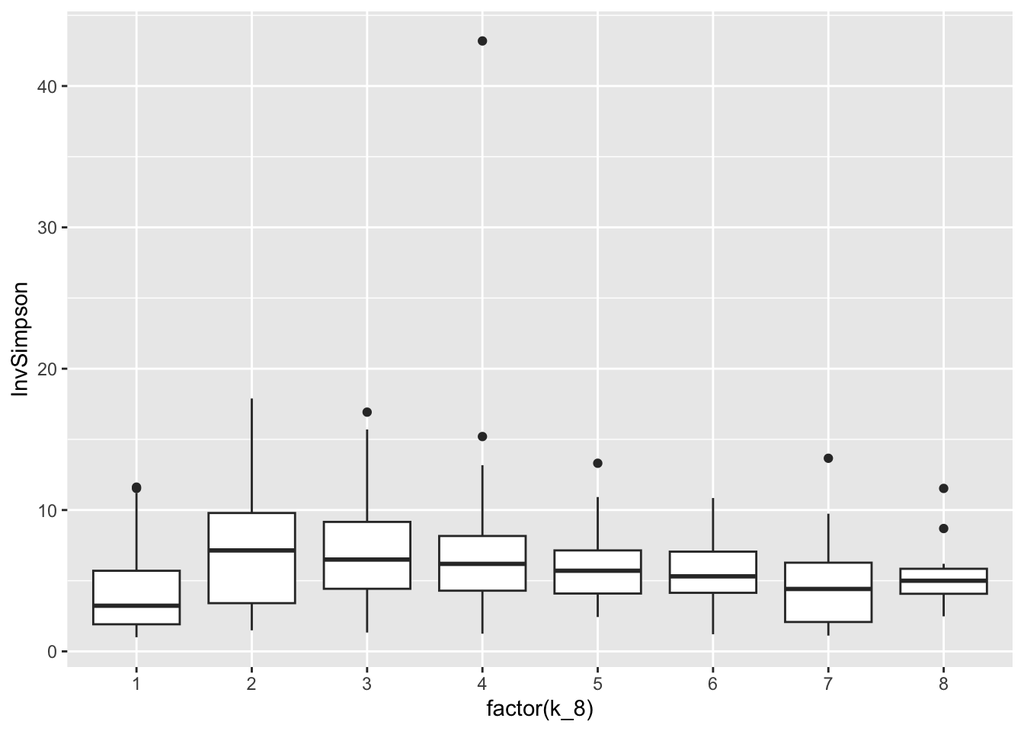

```r
ggplot(new_sam, aes(x = factor(k_8), y = InvSimpson)) + geom_boxplot()
```

```r
pairwise.wilcox.test(new_sam$InvSimpson, new_sam$k_8,
                 p.adjust.method = "BH")
```

```
##
##  Pairwise comparisons using Wilcoxon rank sum test with continuity correction
##
## data:  new_sam$InvSimpson and new_sam$k_8
##
##   1       2       3       4       5       6       7
## 2 8.6e-07 -       -       -       -       -       -
## 3 2.9e-07 0.84913 -       -       -       -       -
## 4 8.6e-07 0.84567 0.64404 -       -       -       -
## 5 1.9e-05 0.24557 0.15080 0.36961 -       -       -
## 6 0.00011 0.15623 0.05600 0.15623 0.64404 -       -
## 7 0.41844 0.00188 0.00100 0.00378 0.01910 0.06824 -
## 8 0.05510 0.15623 0.05378 0.08369 0.21464 0.42706 0.39486
##
## P value adjustment method: BH
```

The only Significant groups: - 2 v 1 - 3 v 1 - 4 v 1 - 5 v 1 - 6 v 1 - 7 v 2 - 7 v 3 - 7 v 4 - 7 v 5

#### alpha div summary

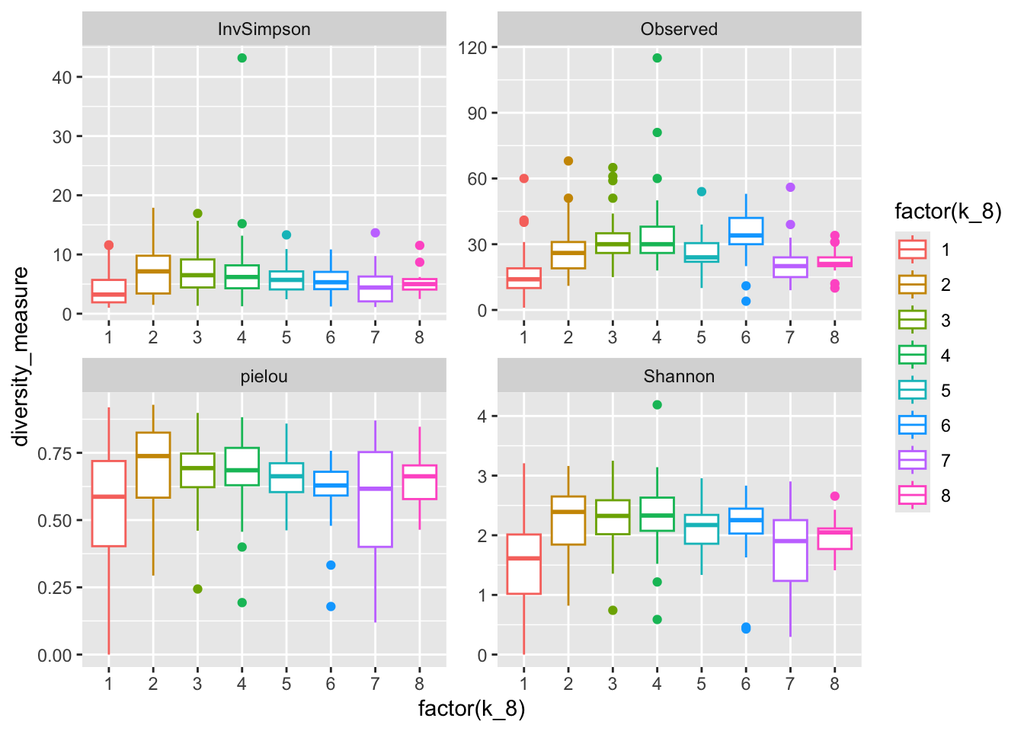

```r
new_sam %>%
  pivot_longer(., cols = c("Observed", "Shannon", "pielou", "InvSimpson"), names_to = "diversity", values_to = "diversity_measure") %>%
  ggplot(., aes(x = factor(k_8), y = diversity_measure, color = factor(k_8))) +
  geom_boxplot() +
  facet_wrap(~diversity, scales = "free")
```

# Contribution Plots

### Building cluster contrib.

```r
color_dfs$cdf_shortg <- color_dfs$cdf %>% mutate(genus_short_name= if_else(Top_Genus=="Other", group, Top_Genus))

color_dfs$mdf_shortg <- color_dfs$mdf %>% mutate(genus_short_name= if_else(Top_Genus=="Other", as.character(group), as.character(Top_Genus)))

keep <- color_dfs$cdf_shortg$genus_short_name[1:15]
keep <- keep[c(1:8, 10:15)]

color_dfs$cdf_shortg <- color_dfs$cdf_shortg %>% filter(genus_short_name %in% keep)
color_dfs$mdf_shortg <- color_dfs$mdf_shortg %>% filter(genus_short_name %in% keep)

color_dfs$mdf_shortg$genus_short_name <- factor(color_dfs$mdf_shortg$genus_short_name, levels = rev(color_dfs$cdf_shortg$genus_short_name))
```

# Top genera of each cluster

Working through each cluster

```r
ps_g <- ps %>%
  tax_glom(., "Genus")
ps_g <- subset_taxa(ps_g, taxa_sums(ps_g) > 0)

ps_g_rel <- transform_sample_counts(ps_g, function(x) 100* x/sum(x))


ps_1 <- ps_g_rel %>%
  subset_samples(., k_8 == "8")
ps_1 <- subset_taxa(ps_1, taxa_sums(ps_1) > 0)


top5 <- head(sort(rowSums(otu_table(ps_1)), decreasing = TRUE), 5)
top5 <- cbind(as.data.frame(tax_table(ps_1)[names(top5),]), Count = top5)

top5$Genus
```

```
## [1] "Anaerococcus"    "Corynebacterium" "Finegoldia"      "Staphylococcus"
## [5] "Streptococcus"
```

# Dialister in clusters

```r
ps_dia <- ps_g %>%
  subset_taxa(., Genus == "Dialister")
ps_dia <- subset_samples(ps_dia, sample_sums(ps_dia) > 0)

meta_dia <- data.frame(ps_dia@sam_data)

# How many have Dialister in each cluster
table(meta_dia$k_8)
```

```
##
##  1  2  3  4  5  6
##  7 10 34  1 52  6
```

```r
table(meta_ps$k_8)
```

```
##
##  1  2  3  4  5  6  7  8
## 85 89 65 61 59 58 37 19
```

```r
# cluster 5 has the most at 88%... also has the highest percentage of obese men. clusters 7 and 8 have 0 men with dialister (7 has the most healthy BMI men)

table(meta_dia$k_8, meta_dia$Diabetes)
```

```
##
##        0. No 1. Yes
##   1  0     7      0
##   2  3     7      0
##   3  4    28      2
##   4  0     1      0
##   5  3    39     10
##   6  2     4      0
```

```r
table(meta_ps$k_8)
```

```
##
##  1  2  3  4  5  6  7  8
## 85 89 65 61 59 58 37 19
```

```r
meta_ps$dialister <- "No"
meta_ps$dialister[meta_ps$ID %in% meta_dia$ID] <- "Yes"

clin_char <- meta_ps %>%
  select(LUTS_cat, age, Race, BMI_group, Diabetes, Prostatitis, BPH, Cancer_Type, PS_Irritative, PS_Obstructive, dialister, k_8)

clin_table <- CreateTableOne(strata = "k_8", data = clin_char, factorVars = "Race")
print(clin_table)
```

```
##                                 Stratified by k_8
##                                  1             2             3
##   n                                 85            89            65
##   LUTS_cat = moderate/severe (%)    35 (41.2)     43 (48.3)     27 (41.5)
##   age (mean (SD))                73.34 (5.33)  72.25 (5.14)  73.18 (6.14)
##   Race = 2. Other (%)               10 (11.8)     10 (11.2)     11 (16.9)
##   BMI_group (%)
##      healthy_weight                 15 (17.6)     24 (27.0)     13 (20.0)
##      obesity                        26 (30.6)     17 (19.1)     14 (21.5)
##      overweight                     44 (51.8)     48 (53.9)     38 (58.5)
##   Diabetes (%)
##                                      8 ( 9.4)     11 (12.4)      4 ( 6.2)
##      0. No                          65 (76.5)     69 (77.5)     55 (84.6)
##      1. Yes                         12 (14.1)      9 (10.1)      6 ( 9.2)
##   Prostatitis = Yes (%)             25 (29.4)     20 (22.5)     13 (20.0)
##   BPH = Yes (%)                     44 (51.8)     48 (53.9)     29 (44.6)
##   Cancer_Type (%)
##      None                           60 (70.6)     54 (60.7)     42 (64.6)
##      Other                          10 (11.8)     23 (25.8)     10 (15.4)
##      Prostate                       15 (17.6)     12 (13.5)     13 (20.0)
##   PS_Irritative (mean (SD))       4.48 (3.38)   4.53 (2.85)   4.75 (3.04)
##   PS_Obstructive (mean (SD))      3.09 (4.08)   4.24 (4.01)   2.65 (3.04)
##   dialister = Yes (%)                7 ( 8.2)     10 (11.2)     34 (52.3)
##   k_8 (mean (SD))                 1.00 (0.00)   2.00 (0.00)   3.00 (0.00)
##                                 Stratified by k_8
##                                  4             5             6
##   n                                 61            59            58
##   LUTS_cat = moderate/severe (%)    24 (39.3)     33 (55.9)     27 (46.6)
##   age (mean (SD))                73.20 (5.16)  73.80 (5.97)  71.69 (6.04)
##   Race = 2. Other (%)                8 (13.1)      3 ( 5.1)      6 (10.3)
##   BMI_group (%)
##      healthy_weight                 12 (19.7)      6 (10.2)     17 (29.3)
##      obesity                        12 (19.7)     25 (42.4)     11 (19.0)
##      overweight                     37 (60.7)     28 (47.5)     30 (51.7)
##   Diabetes (%)
##                                      5 ( 8.2)      3 ( 5.1)      6 (10.3)
##      0. No                          45 (73.8)     45 (76.3)     42 (72.4)
##      1. Yes                         11 (18.0)     11 (18.6)     10 (17.2)
##   Prostatitis = Yes (%)             12 (19.7)     16 (27.1)     10 (17.2)
##   BPH = Yes (%)                     27 (44.3)     28 (47.5)     28 (48.3)
```

[output cut: 17 more lines]

```
##      overweight                     17 (45.9)     11 (57.9)
##   Diabetes (%)                                                0.751
##                                      3 ( 8.1)      0 ( 0.0)
##      0. No                          27 (73.0)     16 (84.2)
##      1. Yes                          7 (18.9)      3 (15.8)
##   Prostatitis = Yes (%)              6 (16.2)      3 (15.8)   0.558
##   BPH = Yes (%)                     16 (43.2)      7 (36.8)   0.817
##   Cancer_Type (%)                                             0.255
##      None                           24 (64.9)     14 (73.7)
##      Other                           9 (24.3)      1 ( 5.3)
##      Prostate                        4 (10.8)      4 (21.1)
##   PS_Irritative (mean (SD))       4.24 (2.69)   3.74 (2.23)   0.400
##   PS_Obstructive (mean (SD))      3.00 (3.04)   2.95 (3.58)   0.121
##   dialister = Yes (%)                0 ( 0.0)      0 ( 0.0)  <0.001
##   k_8 (mean (SD))                 7.00 (0.00)   8.00 (0.00)  <0.001
```

#### plotting dialister in clusters

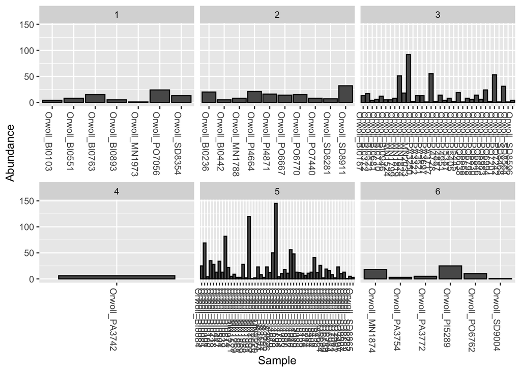

```r
plot_bar(ps_dia, x = "Sample", y = "Abundance") + facet_wrap(~k_8, scales = "free_x")
```

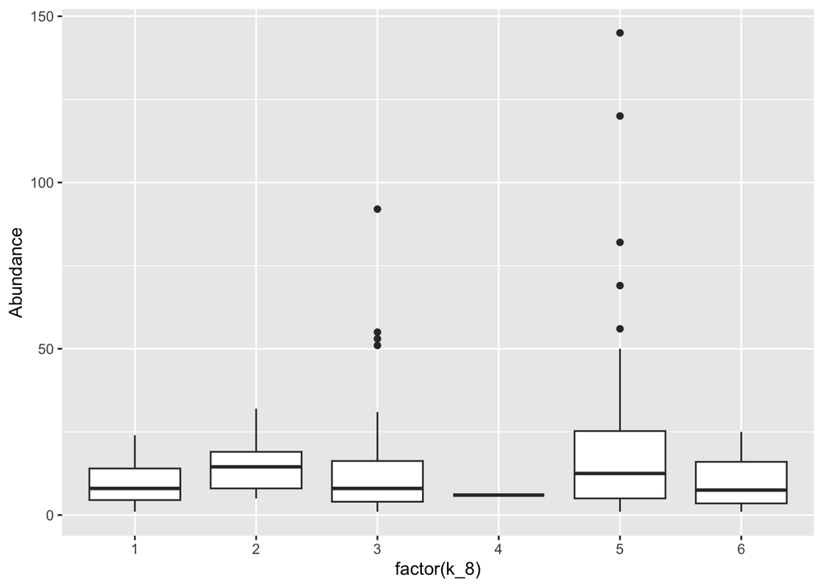

```r
ps_dia %>%
  psmelt() %>%
  ggplot(., aes(x = factor(k_8), y = Abundance)) + geom_boxplot()
```

#### stats testinggggg

```r
d_smelt <- psmelt(ps_dia)
# Test for normality
shapiro.test(d_smelt$Abundance) # Non-normal! ... so anova is not appropriate
```

```
##
##  Shapiro-Wilk normality test
##
## data:  d_smelt$Abundance
## W = 0.65357, p-value = 9.591e-15
```

```r
kruskal.test(Abundance ~ k_8, data = d_smelt)
```

```
##
##  Kruskal-Wallis rank sum test
##
## data:  Abundance by k_8
## Kruskal-Wallis chi-squared = 4.8257, df = 5, p-value = 0.4375
```

```r
pairwise.wilcox.test(d_smelt$Abundance, d_smelt$k_8)
```

```
##
##  Pairwise comparisons using Wilcoxon rank sum test with continuity correction
##
## data:  d_smelt$Abundance and d_smelt$k_8
##
##   1 2 3 4 5
## 2 1 - - - -
## 3 1 1 - - -
## 4 1 1 1 - -
## 5 1 1 1 1 -
## 6 1 1 1 1 1
##
## P value adjustment method: holm
```

```r
# proportion test
# x: # of people with Dialister
# n: total # of people in that group

prop.test(x = c(7, 10, 34, 1, 52, 6, 0, 0), n = c(85, 89, 65, 61, 59, 58, 37, 19), p = NULL, alternative = "two.sided",
          correct = TRUE)
```

```
##
##  8-sample test for equality of proportions without continuity correction
##
## data:  c(7, 10, 34, 1, 52, 6, 0, 0) out of c(85, 89, 65, 61, 59, 58, 37, 19)
## X-squared = 226.2, df = 7, p-value < 2.2e-16
## alternative hypothesis: two.sided
## sample estimates:
##     prop 1     prop 2     prop 3     prop 4     prop 5     prop 6     prop 7
## 0.08235294 0.11235955 0.52307692 0.01639344 0.88135593 0.10344828 0.00000000
##     prop 8
## 0.00000000
```

I actually don’t think a proportion test is what I want to do here… because we’ve shown that dialister is mostly present in obese men, and we’re not accounting for that here? Hm.

```r
dia_perc <- ps_g %>%
  psmelt() %>%
  group_by(k_8) %>%
  filter(Genus == "Dialister") %>%
  count(Abundance > 0) %>%
  mutate(percent_n = (n/sum(n))*100) %>%
  filter(`Abundance > 0` == TRUE) %>%
  select(-(`Abundance > 0`))
```

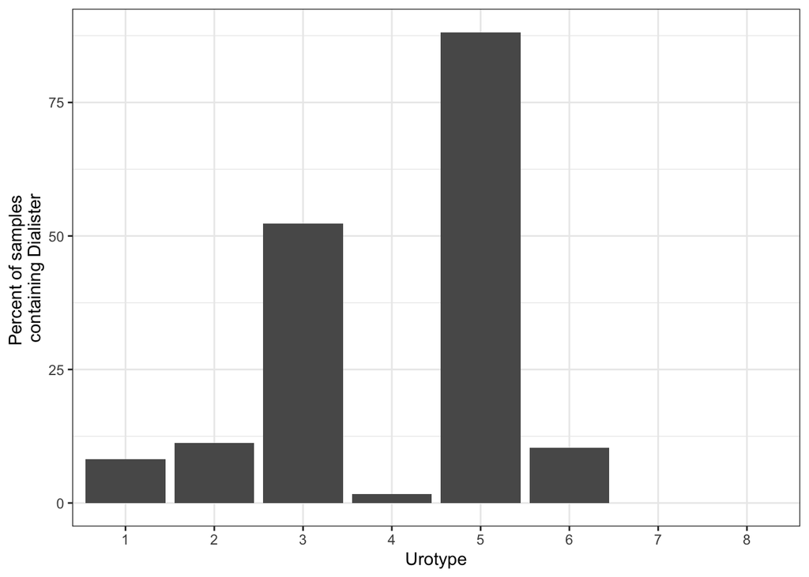

```r
# manually adding back these rows
k_8 <- c(7, 8)
n <- c(0,0)
percent_n <- c(0,0)
dia_df <- data.frame(k_8, n, percent_n)

dia_perc <- rbind(dia_perc, dia_df)




dia_plot <- ggplot(dia_perc, aes(x = factor(k_8), y = percent_n)) +
  geom_col() +
  theme_bw() +
  xlab("Urotype") +
  ylab("Percent of samples \ncontaining Dialister")

dia_plot
```

# Figure 2

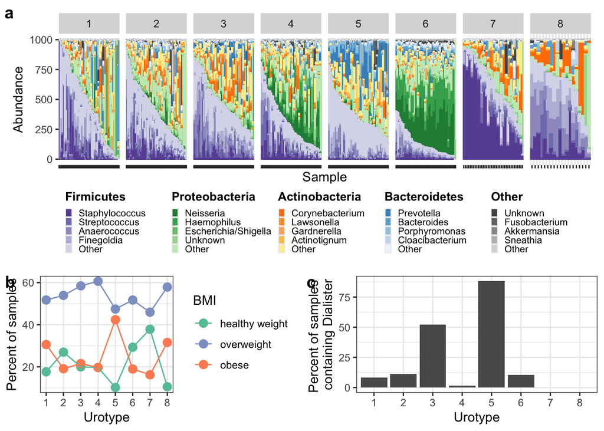

```r
bottom_row <- plot_grid(bmi_traces, dia_plot, labels = c("b", "c"))

plot_grid(clus_plot, bottom_row, labels = c("a", ""), nrow = 2, rel_heights = c(2, 1.2))
```